# Introduction to R

## Overview of R Markdown files

In this course we will often work with R markdown files in class.

```r
1:10
```

```
##  [1]  1  2  3  4  5  6  7  8  9 10
```

## Your First R session

While you are learning the R language, remember that you are learning a new language; thus, we will start rather simply with small analysis tasks and build up to more complicated tasks. Also, you will not remember everything immediately—that’s OK, it’s a natural part of learning a language!

### Installing and loading R packages

R does not enable all of its functionality when you open it. To enable additional functionality we need to load *R packages*. In this class we will often use the `tidyverse` R package to enable better tools for plotting, data manipulation, etc. Below is an example of installation and loading:

```r
# You only need to install a package once
install.packages("tidyverse")
```

```r
# You will need to load the package in each R markdown notebook
library(tidyverse)
```

### Loading data and assignment

Regression models are fit to data sets, so data will play a central role to our applied work in this course. There are multiple ways to load data sets (and we’ll learn more about them later), but we often need to load a `.csv` (comma seperated value) file.

Today, we’ll look at a data set containing information on the weight (pounds) and fuel economy (mpg) of passenger vehicles

```r
# Load the data and assign it a name
mpg <- read.csv("https://github.com/math430-lu/data/raw/master/mpg.csv")
```

### Data frames

The `mpg` object is our first example of a data frame, which is essentially a list of vectors. We can get a first glimpse of our data set in a few ways:

```r
# Printing the first 6 rows
# Note that missing values are denoted by NA
head(mpg)
```

```
##   weight mpg
## 1   3436  18
## 2   3433  16
## 3   3449  17
## 4   3086  14
## 5   2372  24
## 6   2833  22
```

```r
# Printing the last 6 rows
tail(mpg)
```

```
##     weight mpg
## 284   2950  27
## 285   2790  27
## 286   2130  44
## 287   2295  32
## 288   2625  28
## 289   2720  31
```

```r
# Looking at the number of rows and columns
dim(mpg)
```

```
## [1] 289   2
```

```r
# Looking at the structure
str(mpg)
```

```
## 'data.frame':    289 obs. of  2 variables:
##  $ weight: int  3436 3433 3449 3086 2372 2833 2774 2587 2130 1835 ...
##  $ mpg   : num  18 16 17 14 24 22 18 21 27 26 ...
```

```r
# Getting a glimpse of the structure
glimpse(mpg)
```

```
## Observations: 289
## Variables: 2
## $ weight <int> 3436, 3433, 3449, 3086, 2372, 2833, 2774, 2587, 2130, 1...
## $ mpg    <dbl> 18, 16, 17, 14, 24, 22, 18, 21, 27, 26, 25, 24, 25, 26,...
```

```r
# looking at the summary
summary(mpg)
```

```
##      weight          mpg
##  Min.   :1613   Min.   :13.00
##  1st Qu.:2130   1st Qu.:21.00
##  Median :2489   Median :26.00
##  Mean   :2535   Mean   :26.66
##  3rd Qu.:2930   3rd Qu.:31.50
##  Max.   :3465   Max.   :46.60
```

### Syntax: Function application

We have already used functions in R—for example, `summary` is a function—so you have seen the syntax, but we need to make sure we understand what’s happening.

The basic pattern is

```r
object_name <- function_name(arguments)
```

Since we often have a data set of interest, many of our functions will take the form

```r
object_name <- function_name(data, arguments)
```

### Exploring a bivariate relationship

Many factors go into determining what gas mileage a car will achieve. For now, we will focus on the weight of a car. Note that it’s generally understood that heavier cars will get worse fuel economy, but it is not clear how much of an increase in weight will lead to a decrease in fuel economy.

Notation for regression models:

$y_i =$ fuel economy for $i^{\text{th}}$ car

$x_i =$ weight of $i^{\text{th}}$ car

$i = 1, \ldots, n$

$n =$ sample size

#### Scatterplots

The best place to start exploring the relationship between two quantitative variables is with a scatterplot.

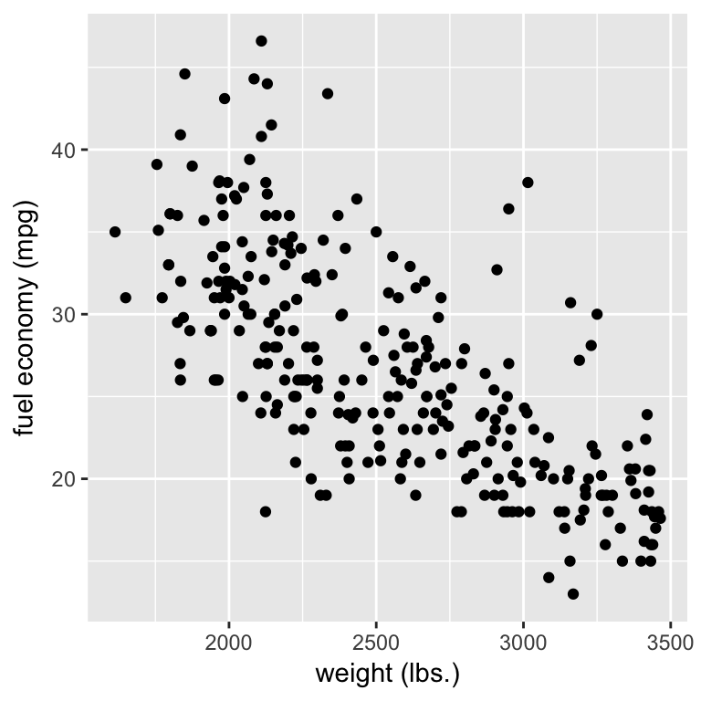

```r
ggplot(data = mpg, mapping = aes(x = weight, y = mpg)) +
  geom_point() +
  labs(x = "weight (lbs.)", y = "fuel economy (mpg)")
```

When examining a scatterplot we must keep the following features in mind:

- Form
- Direction
- Strength
- Outliers / unusual features

#### Correlation

We can also quantify the strength of the linear relationship between two quantitative variables using correlation.

**Formula:**
$$Corr(X, Y) = r = \dfrac{1}{n-1} \sum_{i = 1}^n \left( \dfrac{x_i - \overline{x}}{s_x} \right) \left( \dfrac{y_i - \overline{y}}{s_y} \right)$$

**Key properties:**

1. $-1 \le r \le 1$
2. scale invariant

```r
cor(mpg$weight, mpg$mpg)
```

```
## [1] -0.7105168
```

**Caution:**

Correlation only measures the strength/direction of **linear relationships**

```r
x <- -5:5
y <- x^2
cor(x, y)
```

```
## [1] 0
```

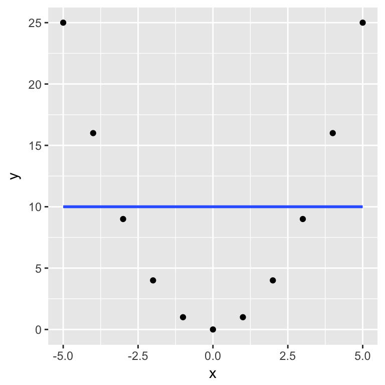

Correlation is **sensitive to outliers**

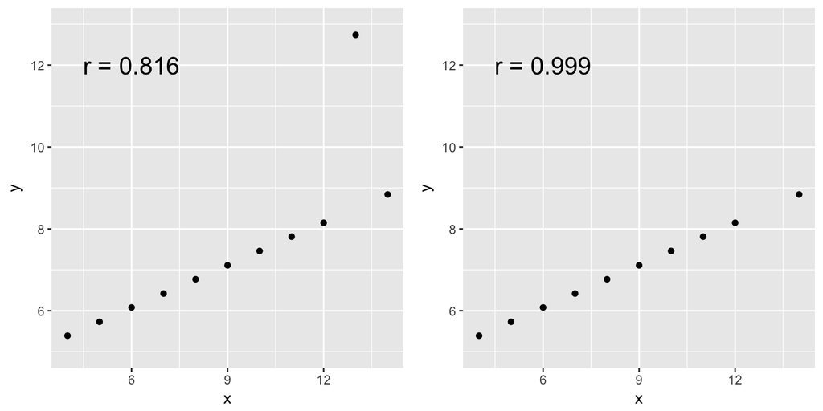